↓ / ↑ or scroll

Metformin XR · model-based bioequivalence · results

# All results — PBPK vs PopPK, both fits, and sensitivity analyses

Every result to date: safe-space decision equivalence (two independent Pumas fits), profile agreement, the IVIVC/identifiability finding, population parameters, and three sensitivity analyses — γ shape, within-subject variability, and study size.

PBPK · PK-Sim PopPK · Pumas units: T50 boundaries in hours · power ≥ 80%

01

Result · decision equivalence — baseline (per-arm fit)

## Safe-space boundaries — PBPK vs PopPK holds

Licensed Pumas · per-arm fit · power ≥ 80% · T50 (h)

| Endpoint | n | PBPK | PopPK | Δ boundary |
| --- | --- | --- | --- | --- |
| Cmax | 48 | 2.00–4.15 | 1.95–4.05 | ≤0.10 |
| Cmax | 86 | 1.80–4.25 | 1.75–4.15 | ≤0.10 |
| AUC₀–t | 48 | 1.00–4.60 | 1.00–4.55 | ≤0.05 |
| AUC₀–t | 86 | 1.00–4.70 | 1.00–4.65 | ≤0.05 |
| AUC_inf | 48 | 1.00–4.95 | 1.00–4.95 | 0.00 |
| AUC_inf | 86 | 1.00–5.05 | 1.00–5.20 | 0.15 |
| Joint (Cmax & AUC₀–t) | 48 | 1.95–4.10 | 1.90–4.05 | ≤0.05 |
| Joint (Cmax & AUC₀–t) | 86 | 1.85–4.25 | 1.75–4.15 | ≤0.10 |

Cmax is the binding endpoint. Joint safe space ≈ **T50 1.9–4.1 h** by both methodologies; boundaries agree to ≤ 0.15 h.

02

Result · decision equivalence — joint (IVIVC) fit

## Safe-space boundaries — joint fit confirmation

Licensed Pumas · joint fit (shared disposition) · power ≥ 80% · T50 (h)

| Endpoint | n | PBPK | PopPK (joint) |
| --- | --- | --- | --- |
| Cmax | 48 | 2.00–4.15 | 1.90–4.10 |
| Cmax | 86 | 1.80–4.25 | 1.70–4.25 |
| AUC₀–t | 48 | 1.00–4.60 | 1.00–4.75 |
| AUC₀–t | 86 | 1.00–4.70 | 1.00–4.90 |
| AUC_inf | 48 | 1.00–4.95 | 1.00–5.45 |
| AUC_inf | 86 | 1.00–5.05 | 1.00–5.80 |
| Joint (Cmax & AUC₀–t) | 48 | 1.95–4.10 | 1.85–4.10 |
| Joint (Cmax & AUC₀–t) | 86 | 1.85–4.25 | 1.70–4.25 |

Decision equivalence is robust to fitting strategy. The joint fit's **AUC_inf runs a bit wider** than PBPK (e.g. n=86: 5.80 vs 5.05) — the unstable extrapolation for slow flip-flop tablets, which is why AUC₀–t is the primary AUC endpoint. Fit: OFV ≈ 6093.6.

03

Result · profile agreement

## PopPK profiles land on the PBPK truth

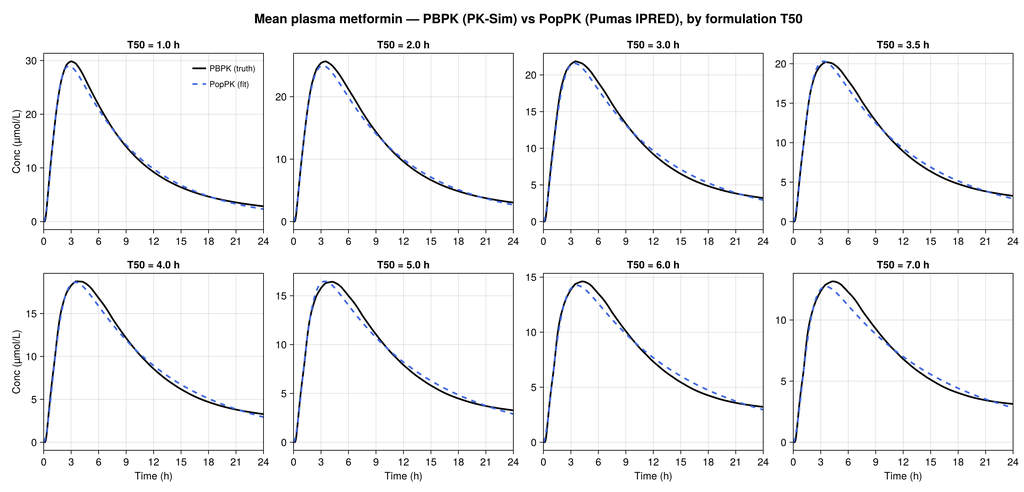

04

Result · the GMR(T50) driver

## Geometric-mean ratio vs T50, with 90% CI

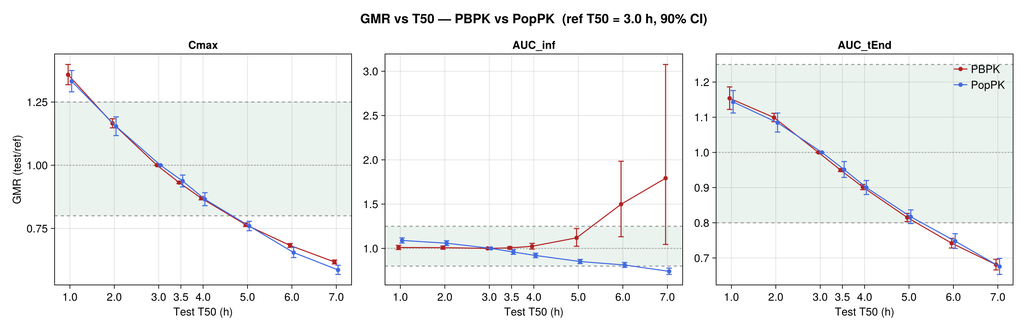

05

Result · safe-space power curves

## Joint-endpoint power vs T50

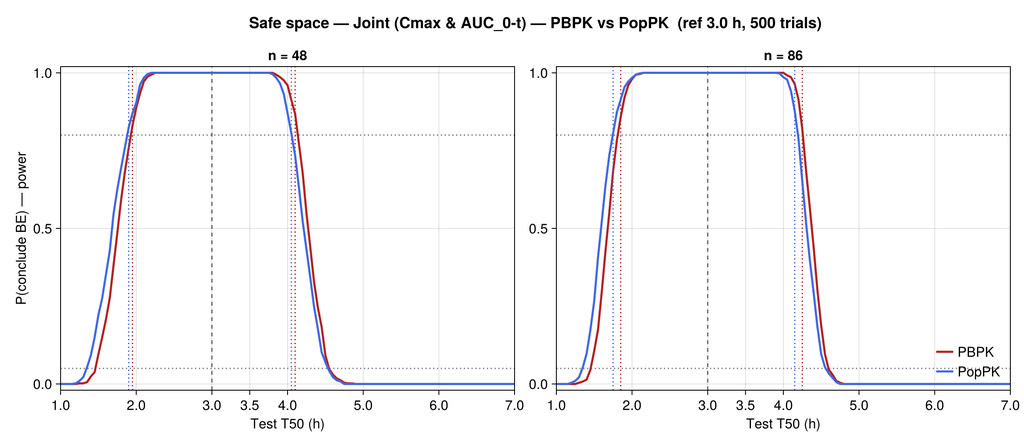

Power to conclude BE (joint Cmax & AUC₀–t) vs T50, n = 48 and 86. PBPK and PopPK curves and their ≥80%-power boundaries nearly coincide. Note how little the band widens from n=48 to n=86 — metformin's low within-subject CV.

06

Result · IVIVC / identifiability

## Release scale α is flat — in both fits

Fitted geometric-mean α (h) vs PBPK T50

| T50 | 1 | 2 | 3 | 3.5 | 4 | 5 | 6 | 7 |
| --- | --- | --- | --- | --- | --- | --- | --- | --- |
| α · per-arm | 1.42 | 1.60 | 1.69 | 1.65 | 1.68 | 1.65 | 1.69 | 1.71 |
| α · joint | 1.43 | 1.57 | 1.68 | 1.67 | 1.72 | 1.71 | 1.70 | 1.76 |

Where the formulation effect went (joint fit, gm)

| T50 | 1 | 4 | 7 |
| --- | --- | --- | --- |
| α (h) | 1.43 | 1.72 | 1.76 |
| CL (L/h) | 10.6 | 12.2 | 14.7 |
| Vc (L) | 86 | 130 | 190 |

Joint IVIVC exponent **slope = 0.10** (≈ flat). The release-rate signal is **not identifiable** from sparse 1-compartment data (flip-flop): it is absorbed into apparent CL and Vc, which rise with T50 instead of α. **PopPK reproduces the BE decision, not the release mechanism.**

07

Result · population parameter estimates

## Fitted parameters

Per-arm fit — by formulation

| T50 | α | γ | CL | Vc | σ |
| --- | --- | --- | --- | --- | --- |
| 1.0 | 1.42 | 1.74 | 10.3 | 83.7 | 0.17 |
| 2.0 | 1.60 | 1.67 | 10.6 | 95.2 | 0.19 |
| 3.0 | 1.69 | 1.71 | 11.2 | 111.7 | 0.20 |
| 3.5 | 1.65 | 1.73 | 11.7 | 121.2 | 0.20 |
| 4.0 | 1.68 | 1.75 | 12.2 | 131.8 | 0.20 |
| 5.0 | 1.65 | 1.75 | 13.1 | 152.9 | 0.22 |
| 6.0 | 1.69 | 1.66 | 13.7 | 177.4 | 0.24 |
| 7.0 | 1.71 | 1.71 | 15.0 | 201.1 | 0.25 |

Joint fit — single population

| Parameter | Estimate |
| --- | --- |
| α (release scale, ref) | 1.62 h |
| slope (IVIVC exponent) | 0.10 |
| γ (input shape) | 1.71 |
| CL | 12.1 L/h |
| Vc | 129 L |
| σ (prop. residual) | 0.21 |
| OFV | 6093.6 |

Per-arm: CL/Vc drift upward with T50 (the flip-flop leak). Joint: shared disposition, but the leak reappears through the random effects — hence flat α.

08

Sensitivity 1 · release shape γ cross-check

## γ estimated vs γ fixed at 1.0

Safe space (T50 h) — license-free joint cross-check

| Endpoint · n | PBPK | γ est (≈0.8) | γ = 1.0 |
| --- | --- | --- | --- |
| Cmax · 48 | 2.00–4.15 | 1.70–4.60 | 1.00–6.40 |
| Cmax · 86 | 1.80–4.25 | 1.50–4.80 | 1.00–6.60 |
| Joint · 48 | 1.95–4.10 | 1.65–4.55 | 1.00–6.35 |
| Joint · 86 | 1.85–4.25 | 1.50–4.80 | 1.00–6.60 |

α (est) 3.2→11.0 vs α (γ=1) 0.9→3.1 across T50 1→7 h.

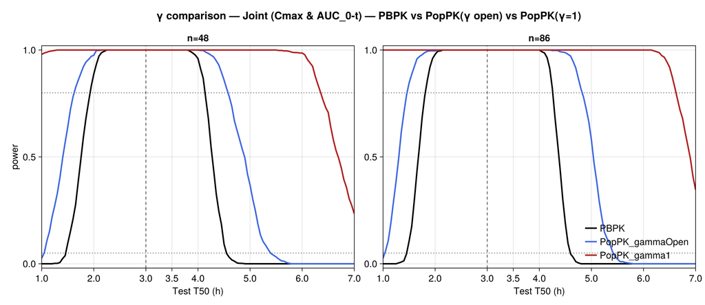

PBPK vs γ estimated vs γ = 1.0. Fixing γ to the dissolution β = 1.0 **inflates the safe space badly** — the in-vivo input shape is not the in-vitro dissolution shape, so γ must be estimated. *(License-free proxy; illustrative.)*

09

Sensitivity 2 · within-subject variability

## Low-variability (ER) vs high-variability (IR) CV

PBPK safe space (T50 h) · ER CV vs IR CV

| Endpoint · n | ER CV | IR CV |
| --- | --- | --- |
| Cmax · 48 | 2.00–4.15 | 2.30–3.75 |
| Cmax · 86 | 1.80–4.25 | 2.10–3.90 |
| AUC₀–t · 48 | 1.00–4.60 | 1.05–4.40 |
| Joint · 48 | 1.95–4.10 | 2.30–3.70 |
| Joint · 86 | 1.85–4.25 | 2.15–3.90 |

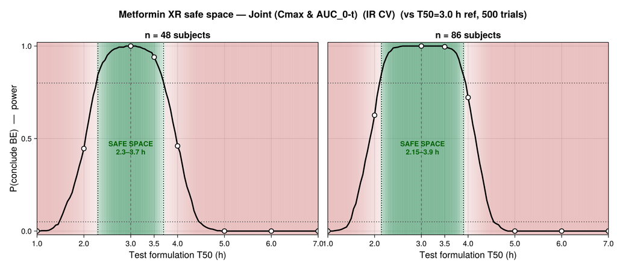

Joint-endpoint safe space under the high-variability (IR) within-subject CV — the shaded ≥80%-power band contracts markedly versus the ER baseline.

10

Sensitivity 3 · study size · and results index

## Study size, and everything at a glance

### Study size n

48 → 86

Joint safe space widens only ~0.1 h per side (1.95–4.10 → 1.85–4.25). A low-within-subject-CV signature — bigger trials barely help.

### Reference

T50 3.0 h

### Absolute exposure

~3–4×

PBPK over-predicts vs clinic (Cmax 2.8 µg/mL). Shared offset → cancels in the ratio → no effect on the safe space.

Joint-endpoint safe space (T50 h) — master summary

| Run / scenario | n = 48 | n = 86 |
| --- | --- | --- |
| PBPK (truth) | 1.95–4.10 | 1.85–4.25 |
| PopPK · per-arm | 1.90–4.05 | 1.75–4.15 |
| PopPK · joint | 1.85–4.10 | 1.70–4.25 |
| PBPK · IR (high CV) | 2.30–3.70 | 2.15–3.90 |
| PopPK · γ = 1.0 (proxy) | 1.00–6.35 | 1.00–6.60 |

decision equivalence: holds IVIVC: not identifiable (flat α) CSVs/figures in the export folders + comparison docs

11